# *Notogorgius poutii*

A CKMR model for fish-like species, with POPs and HSPs

```r
library(tidyverse) # for the tutorial
library(data.table)

## CKMR libraries
library(mvbutils) # various low-level utilities, eg cq()
library(offarray) # arrays/vectors don't have to start at 1 any more! Freedom!
library(debug) # so we can watch the fun
library(atease)

## for plotting:
library(ggplot2)
library(cowplot); theme_set(theme_cowplot(font_size=10))
library(colorspace)
library(patchwork)

source('../ckmr_funs.r') # tutorial functions
source('../plonk/turn_off_bc.r') # turn-off the byte-compiler (required for offarray to work)

load( '../samp_notog1.rda') # object samp_notog1
samp_notog1 <- subset_samples( samp_notog1, Sex=='F') # keeping females only for the exercise
agemat <- samp_notog1@public$Amat # age at maturity for this species
```

In this CKMR exercise we combine two types of close-kin marks (parent-offsprings and half-siblings) in order to scale population size for a species where fecundity changes with age (i.e. fish-like).

As this is a commercially-exploited species, the population model will also account for annual catch data.

# Species overview

Southern sweetlips (*Notogorgius poutii*) might be described as a “classic temperate-latitude teleost”. It is an epibenthic schooling species, with a pelagic larval phase. Tagging studies show that adults can sometimes move long distances within the single known coastal population.

The lifespan of southern sweetlips is at least 12 years, with maturity around age 5 and strong growth thereafter, and a maximum weight of about 15kg. Weight-at-age is known but there is some uncertainty about fecundity-at-age. It can be aged reliably, and growth has been well-studied; there is little apparent difference between the sexes. There is a single annual spawning season in winter.

It has been fished commercially for about 20 years, mostly in summer with trawls and auto-longlines; adults make up the bulk of of the catch, but there have been considerable shifts in composition associated with changes in gear as the fishery has developed. In recent years there have been suggestions–loudly contested in some quarters–that catch rates have dropped alarmingly, but the assessment is very uncertain. Fortunately, an extensive program of length-stratified genetic and biological sampling over the past 10 years, has paved the way for CKMR.

# Available samples

We can load the data in the usual manner from `samp_notog1.rda`…

```r
load( '../samp_notog1.rda') # object samp_notog1
names(samp_notog1)
```

```
[1] "Samps" "POPs"  "MHSPs" "PHSPs"
```

```r
samp_notog1 <- subset_samples( samp_notog1, Sex=='F') # keeping females only for the exercise
```

… and let the trusty `boring_data_prep` do some of the heavy (data preparation) lifting.

```r
maxoff_age <- samp_notog1@public$Amat+2 # setting maximum offspring age from known parameters of maturity-at-age curve
lglk_notog <- generic_lglk_fish # a copy that will be taught about delfi_C data
env <- boring_data_prep_fish( samp_notog1,
                             MAX_OFF_AGE=maxoff_age,
                             prev_env=environment( lglk_notog))
```

`boring_data_prep_fish` prepares the following key objects to be used during model fit:

- `n_comp_POP_BYA`: pairwise comparisons between possible juvenile birth years and adults based on age and sampled year — comparisons only allowed if adults born before juveniles and juveniles born before year of adult sampling
- `n_POP_BYA`: number of POPs detected by juvenile birth year, year of adult sampling and adult age
- `n_comp_HSP_B1B2`: pairwise comparisons between all possible juvenile sampled—comparisons only allowed across different year cohorts and in one direction (oldest vs. youngest sibling)
- `n_HSP`: number of HSPs detected across all possible cohort comparisons

… and a few extra housekeeping ones.

Before we try fitting the model, we start by examining our dataset.

```r
samp_notog1$Samps$poss_par <- samp_notog1$Samps$A >= agemat
samp_notog1$Samps$poss_off  <- samp_notog1$Samps$A <= maxoff_age
```

You might have noticed that individuals of age 5 to 7 are classified as both juveniles and adults. That’s because of the maturity-at-age curve for this species whereby some individuals start spawning from age 5 onwards. As we do not know the maturity status of each individual, we need to account for the possibility that individuals from age 5 onwards might have started spawning (and thus could be parents).

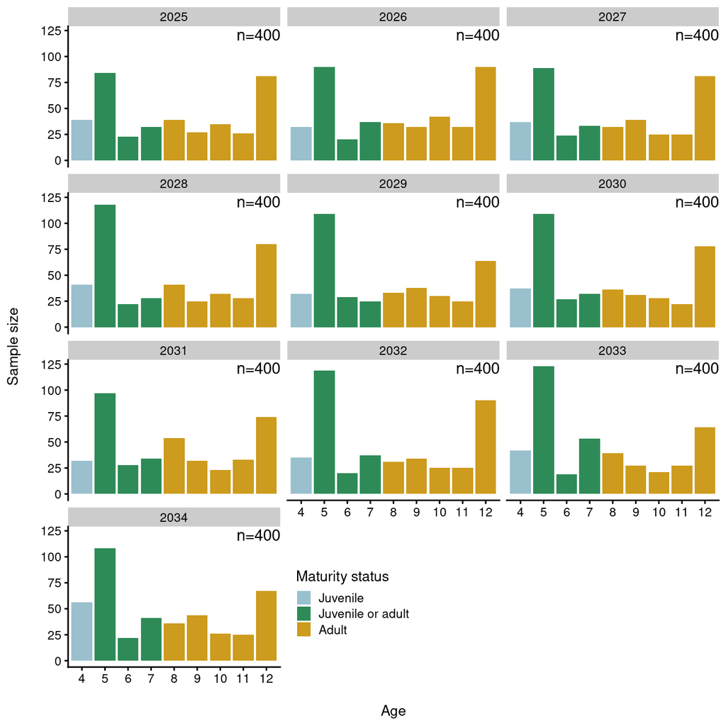

```r
# Fig: barplot of age distribution by status per year?


samp_notog1$Samps$ID <- 1:nrow(samp_notog1$Samps)
samp_notog1$Samps$mat_stat <- with(samp_notog1$Samps, case_when(poss_off & !poss_par ~ 'Juvenile',
                                                                !poss_off & poss_par ~ 'Adult',
                                                                poss_off & poss_par ~ 'Juvenile or adult',
                                                                TRUE ~ 'Undetermined'))

## Aggregate dataframe to count samples by sampling year / age / maturity status
samplmatstat <- samp_notog1$Samps %>% group_by(Y, A, mat_stat) %>% tally()

ggplot(samplmatstat, aes(as.factor(A), y=n, fill=mat_stat)) +
    geom_bar(stat='identity') +
    facet_wrap(~Y, ncol=3) +
    xlab('\nAge') + ylab('Sample size\n') +
    scale_fill_manual('Maturity status', values=c(Juvenile='lightblue3', `Juvenile or adult`='seagreen', Adult='goldenrod3')) +
    theme(legend.position=c(0.35, 0.1)) +
    annotate('text', x=Inf, y=Inf, label='n=400', vjust=1.2, hjust=1)
```

```r
samp_notog1$Samps$B <- with(samp_notog1$Samps, Y - A) # add birth year B

# Aggregate samples by age / birth year / maturity year
parentcnts <-  samp_notog1$Samps %>% filter(poss_par) %>%
    mutate(X=A) %>% group_by(Y, X) %>% tally() %>% mutate(lab='Adult age')
parentcntsby <-  samp_notog1$Samps %>% filter(poss_par) %>% mutate(X=B) %>%
    group_by(Y, X) %>% tally() %>% mutate(lab='Birth year')
parentcntsmat <-  samp_notog1$Samps %>% filter(poss_par) %>%
    mutate(M=B+agemat, X=M) %>% group_by(Y, X) %>% tally() %>% mutate(lab='Maturity year')
parentsmry <- bind_rows(parentcnts, parentcntsby, parentcntsmat)
```

If we take a closer look at the adult samples, we can see that the (possible) adults were born between 2013 and 2029 and matured between 2018 and 2034.

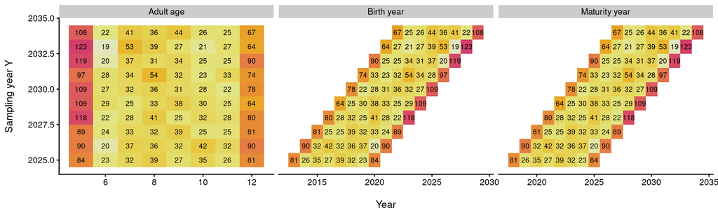

Distribution of adult counts by sampling year vs. adult age (left), adult birth year (center) and adult maturity year (right).

```r
ggplot(parentsmry, aes(X, Y, fill=n)) + geom_tile(show.legend=FALSE) +
    scale_fill_gradientn(colours=rev(heat_hcl(40))) +
    geom_text(aes(label=n), size=2.5) +
    facet_wrap(~lab, nrow=1, scales='free_x') +
    xlab('\nYear') + ylab('Sampling year Y\n')
```

```r
# Aggregate samples by age / birth year / maturity year
parentcnts <-  samp_notog1$Samps %>% filter(poss_par) %>%
    group_by(Y, A) %>% tally() %>% mutate(lab='Adult age')

s1 <- ggplot(parentcnts, aes(A, Y, fill=n)) + geom_tile(show.legend=FALSE) +
    scale_fill_gradientn(colours=rev(heat_hcl(40))) +
    geom_text(aes(label=n), size=3) +
    xlab('\nAdult age A') + ylab('Sampling year Y\n')

offsprngcnts <-  samp_notog1$Samps %>% filter(poss_off) %>%
    group_by(Y) %>% tally()

s2 <- ggplot(offsprngcnts, aes(1, Y, fill=n)) + geom_tile(show.legend=FALSE) +
    scale_fill_gradientn(colours=rev(heat_hcl(40))) +
    geom_text(aes(label=n), size=3) + scale_x_continuous(breaks=1, label='Juvenile') +
    xlab('\n') + ylab('')

s1 + s2 + plot_layout(nrow=1, widths=c(10, 1))
```

Let’s compare adult birth years to juvenile birth years, since, at the very least, adults can only be parents if they were alive in the juvenile cohort birth year:

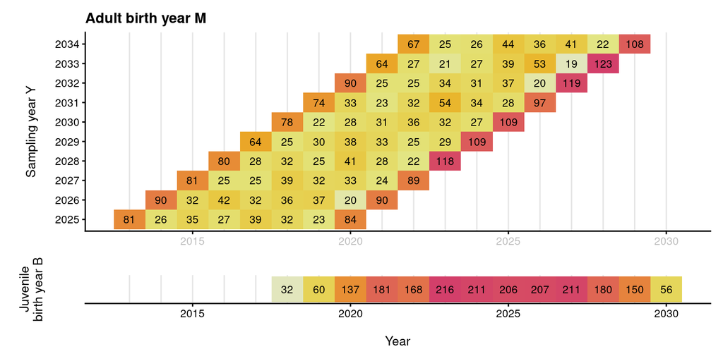

```r
offsprcnts <-  samp_notog1$Samps %>% filter(poss_off) %>% group_by(B) %>% tally()

xlms <- c(min(parentcntsby$X, offsprcnts$B),
          max(parentcntsby$X, offsprcnts$B))

p3 <- ggplot(parentcntsby, aes(X, as.factor(Y), fill=n)) +
    geom_vline(xintercept=xlms[1]:xlms[2], colour='grey90') +
    geom_tile(show.legend=FALSE) +
    scale_fill_gradientn(colours=rev(heat_hcl(40))) + geom_text(aes(label=n), size=3) +
    theme(axis.text.x=element_text(colour='grey')) +
    coord_cartesian(clip='off') +
    ylab('\nSampling year Y\n') + xlab('') + ggtitle('Adult birth year M')

o1 <- ggplot(offsprcnts, aes(y=1, (B), fill=n)) +
    geom_vline(xintercept=xlms[1]:xlms[2], colour='grey90') +
    geom_tile(show.legend=FALSE) +
    scale_fill_gradientn(colours=rev(heat_hcl(40))) +
    geom_text(aes(label=n), size=3) +
    xlab('\nYear') + ylab('Juvenile\nbirth year B') +
    coord_cartesian(clip='off') +
    theme(axis.text.y=element_blank(), axis.line.y=element_blank(),
          axis.ticks.y=element_blank())

p3 +
    xlim(xlms + c(-0.5, 0.5)) + o1 + xlim(xlms + c(-0.5, 0.5)) + plot_layout(ncol=1, heights=c(7, 1))
```

```r
env$n_comp_POP_BYA[2021, 2028, 8]
```

```
, , Aad = 8

         Yad
Bju       [,2028]
  [2021,]    7421
```

… and the number of comparisons is zero for birth years smaller or equal to `2020` (as the adult wasn’t born) or greater or equal than `2028` (as the adult was dead from fishing).

```r
env$n_comp_POP_BYA[, 2028, 8]
```

```
, , Aad = 8

         Yad
Bju       [,2028]
  [2018,]       0
  [2019,]       0
  [2020,]       0
  [2021,]    7421
  [2022,]    6888
  [2023,]    8856
  [2024,]    8651
  [2025,]    8446
  [2026,]    8487
  [2027,]    8651
  [2028,]       0
  [2029,]       0
  [2030,]       0
```

(Ps: use `dimseq(env$n_comp_POP_BYA)` to look at the dimensions of this `offarray` object.)

In reality (and as we’ve seen in previous examples) the adults can only be possible parents if they were alive *and* mature when the juveniles were born, but that’s handled later within the likelihood computation. Still, comparing the number of available samples of adults by maturity year vs. juvenile birth years tell us the time period for which our CKMR algorithm is likely to be most informative. First we can look at our the distribution of our detected POPs (which should match the numbers in `env$n_POP_BYA`).

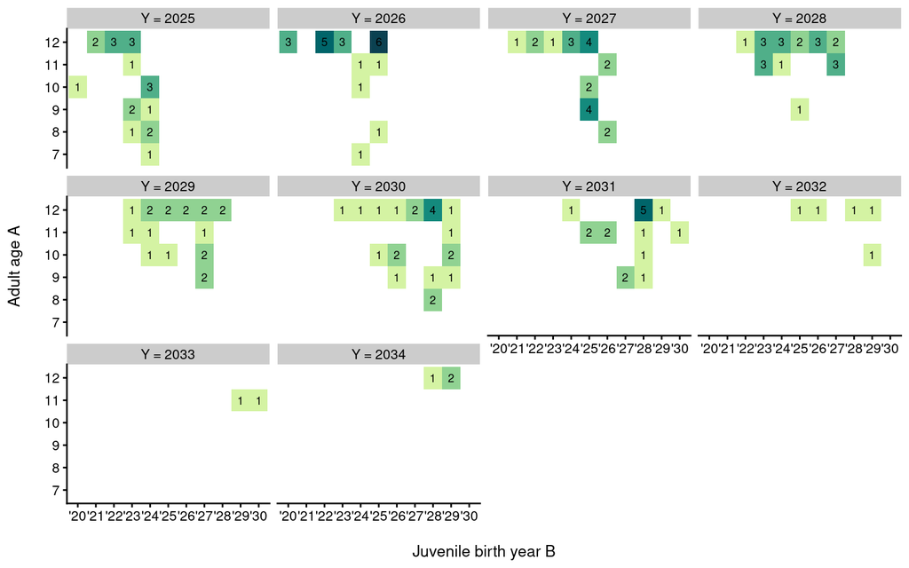

Distribution of detected POPs across sampling years, adult ages, and juvenile birth years. Note: we are only considering POPs where juveniles were born *before* year-of-adult-capture. This avoids a bias when adults caught within-spawning-season don’t reach their full reproductive output that year.

```r
popdf <- with(samp_notog1$Samps,
              data.frame(Y=Y[samp_notog1$POPs[,1]],
                         A=A[samp_notog1$POPs[,1]],
                         B=B[samp_notog1$POPs[,2]])) %>%
    filter(Y > B) #

npop <- popdf %>% group_by(Y, A, B) %>% tally %>%
    mutate(Y=paste('Y =', Y))

ggplot(npop, aes(as.factor(B), as.factor(A), fill=n)) +
    geom_tile(show.legend=FALSE) +
    scale_fill_gradientn(colours=rev(sequential_hcl(40, 'Emrld'))) +
    geom_text(aes(label=n), size=2.5) +
    facet_wrap(~Y) +
    scale_x_discrete(breaks=env$min_Bju:env$max_Bju,
                     labels=paste0("'",substr(env$min_Bju:env$max_Bju, 3, 4))) +
    ylab('Adult age A\n') + xlab('\nJuvenile birth year B')
```

A couple of things stand out: most of our POPs are detected for older adults and for juvenile birth years between `2024` and `2028`.

```r
sumover(env$n_POP_BYA, c('Yad', 'Aad'))
```

[output not shown]

The increased contribution of older adults is expected for fish-like species, as older adults are more fecund. We can also look at the number of pairwise combinations possible per juveniles per birth year (or, the number of marks released):

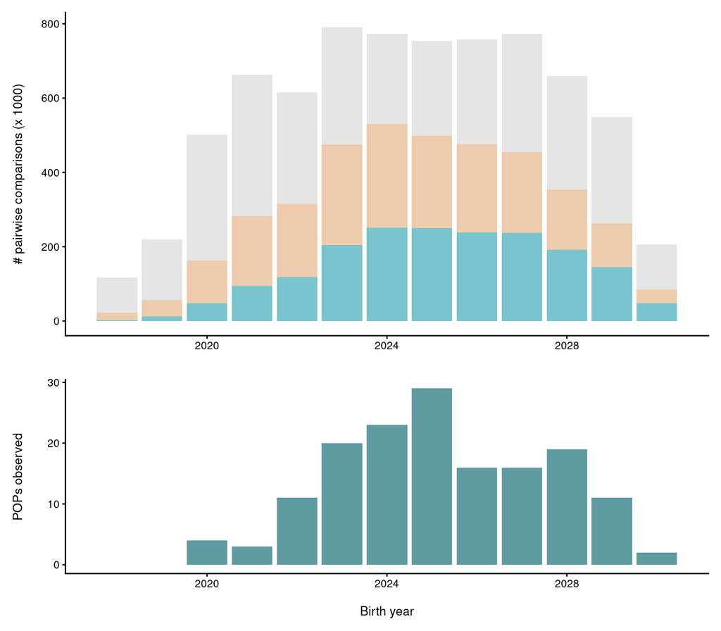

```r
pp <-  samp_notog1$Samps %>% filter(poss_par) %>% group_by(Y, A, B) %>% tally()
oo <-  samp_notog1$Samps %>% filter(poss_off) %>% group_by(B) %>% tally() %>% rename(BirthJuv=B, NumJuv=n)
oopp <- expand(pp %>% group_by(Y, A, B, n), ungroup(oo))
oopp$AllComp <- with(oopp, n * NumJuv)
oopp$BoringComp <- with(oopp, ifelse( B < BirthJuv & Y > BirthJuv,  n * NumJuv, 0))
oopp$StrictComp <- with(oopp, ifelse( (B + 5) <= BirthJuv & Y > BirthJuv,  n * NumJuv, 0))
oopp2 <- oopp %>% group_by(BirthJuv) %>% summarise(AllComps=sum(AllComp/1000), Boring=sum(BoringComp/1000), CKMR=sum(StrictComp/1000))
cp1 <- ggplot(oopp2, aes(BirthJuv, AllComps)) + geom_bar(stat='identity', fill='grey90') +
    geom_bar(stat='identity', aes(y=Boring), fill='peachpuff2') +
    geom_bar(stat='identity', aes(y=CKMR), fill='cadetblue3') +
    xlab('') + ylab('# pairwise comparisons (x 1000)\n') + xlim(range(oopp$BirthJuv) + c(-0.5, 0.5))

popby <- popdf %>% group_by(B) %>% tally
cb35 <- colorRampPalette(c('cadetblue3', 'cadetblue4'))(4)[3]
cp2 <- ggplot(popby, aes(B, n)) + geom_bar(stat='identity', fill=cb35) +
        xlab('\nBirth year') + ylab('POPs observed\n') + xlim(range(oopp$BirthJuv) + c(-0.5, 0.5))

cp1 + cp2 + plot_layout(heights=c(5, 3), ncol=1)
```

## Half-sibling pairs

So far we have considered direct marks only, whereby a juvenile “marks” its parent upon being born and for the parent mark to be recaptured we have to sample both the juvenile and its marked parent (i.e., POPs). Let’s now move on to the `indirect’ marks, the half-sibling pairs (HSPs). Here, the parent mark is recaptured when we have sampled two (or more) of its offspring over different cohorts. In the process, we found out a few things about the parent from the characteristics of its offspring (even though we’ve never actually seen the parent!). First, the parent was mature when the oldest of the sibling was born and second, the parent was still alive when the youngest of the sibling was born. For fish-like species, we also know that the parent contributed more to the total reproductive output the year that the youngest of the sibling was born (since it grew in size and thus, increased its fecundity).

Let’s look at the number of possible combinations between potential half-sibling pairs. First, note that we’re not accounting for adults in HSPs comparison to avoid including grand-parents. So we’re only considering samples that are possibly juveniles (i.e. 7 years old or younger).

For half-siblings, we are only interested in the year they were born (i.e. the cohort they belong to). The dataset has a similar format to that for POPs, that is two columns that index the record in `samp_notog1$Samps`. Of note the pairs are ordered (by convention) to list the youngest of the sibling first, the oldest second. Comparisons should only be made in one direction (to avoid double-counting) so we pick oldest to youngest and retain it (including in likelihood calculations).

```r
head(samp_notog1$MHSPs)
```

```
     keeps1 keeps2
[1,]     51    263
[2,]    130    530
[3,]    130    531
[4,]    136    241
[5,]    211    346
[6,]    279    955
```

We can look at the detected (M)HSPs by combination of birth years and compare that to the number of possible pairwise combinations between different birth years (see `env$n_comp_MHSP`).

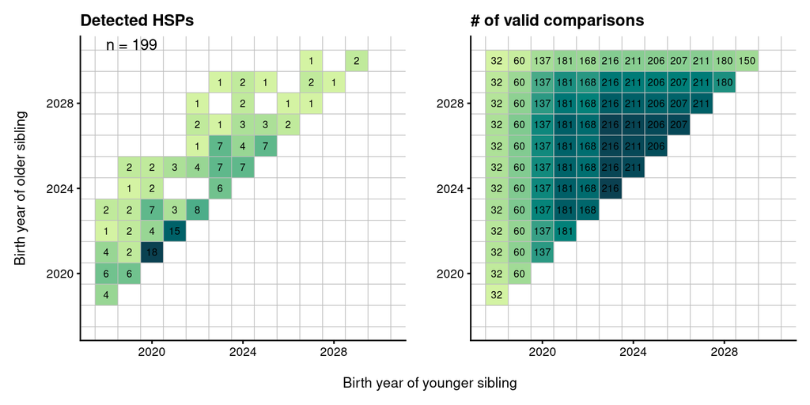

```r
bbdf <- with(samp_notog1, data.frame(B1=Samps$B[MHSPs[,1]],
                                     B2=Samps$B[MHSPs[,2]]))
bbdfag <- bbdf %>% group_by(B1, B2) %>% tally # count by combinations of birth year

hxl <- range(filter(samp_notog1$Samps, poss_off)$B) + c(-0.5, 0.5)

hc1 <- ggplot(bbdfag, aes(B1, B2, fill=n)) + geom_tile(show.legend=FALSE) +
    geom_text(aes(label=n), size=2.5) +
    scale_fill_gradientn(colours=rev(sequential_hcl(40, 'Emrld'))) +
    geom_hline(yintercept=seq(hxl[1], hxl[2]), colour='grey', size=0.25) +
    geom_vline(xintercept=seq(hxl[1], hxl[2]), colour='grey', size=0.25) +
    annotate('text', x=-Inf, y=Inf, label=paste('n =', nrow(bbdf)), vjust=1.2, hjust=-0.5) +
    xlab('') +
    ylab('Birth year of older sibling\n') + xlim(hxl) + ylim(hxl) +

    ggtitle('Detected HSPs')

hspdf <- samp_notog1$Samps %>% filter(poss_off) %>%
    group_by(B) %>% tally
## create df with all possible pairwise combinations of birthyears,
## filter to only keep combinations where B2 > B1 (note '>'---no same cohort comparisons)
hspcomp <- expand(hspdf %>% group_by(B, n),
                  rename(hspdf, B2=B, n2=n) %>% group_by(B2, n2)) %>% filter(B2 > B)

hspcomp$Num <- with(hspcomp, n * n2) # number of pairwise comparisons

hc2 <- ggplot(hspcomp, aes(B, B2, fill=Num)) +
 geom_tile(show.legend=FALSE, colour='grey') +
    geom_text(aes(label=n), size=2.5) +
    scale_fill_gradientn(colours=rev(sequential_hcl(40, 'Emrld'))) +
    xlab('\nBirth year of younger sibling') +
    ylab('') + xlim(hxl) + ylim(hxl) +
    geom_hline(yintercept=seq(hxl[1], hxl[2]), colour='grey', size=0.25) +
    geom_vline(xintercept=seq(hxl[1], hxl[2]), colour='grey', size=0.25) +
    ggtitle('# of valid comparisons')

hc1 + hc2 + theme(axis.title.x=element_text(hjust=-0.85)) + plot_layout(nrow=1)
```

It’s also useful to look at the age difference between the detected half-siblings, as that tells us something about adult survival (and will indeed inform the population model with regards to $M$):

[figure not shown]

```r
bbdf$diff <- with(bbdf, B2 - B1)

ggplot(bbdf, aes(diff)) + geom_histogram(colour='white') +
    xlab('\nAge difference') +
    ylab('Count\n')
```

```r
# Exercise: compare that to the possible age difference given all possible pairwise comparisons
# hspcomp$diff <- with(hspcomp, B2 - B1)
# table(with(hspcomp, rep(diff, Num)))
```

# Model definition

For fish-like species we need an age-structured model since fecundity changes with age. In the case of Southern sweetlips, we also need one that can include extractions (cf. fisheries catches). The population model we use here has four parameters:

- `Ncad_y0` ($N_0$): total *catchable* abundance in year 1 (i.e. not dealing with selectivity here)
- `aslope_y0`: parameter determining age-structure in the first year
- `M`: natural mortality
- `wtfecpar`: power-coefficient of the weight-fecundity relationship

We follow the usual CKMR modelling framework, that is, we start by unpacking the population parameters:

```r
Ncad_y0 <- exp( params[ 1])
aslope_y0 <- exp( params[ 2])
M <- exp( params[ 3])
wtfecpar <- exp( params[ 4])
fecata <- (weight ^ wtfecpar) * (1:AMAX >= Amat) # max age, see env$AMAX
```

Abundance in the first year is the product of $N_0$ and a scaled `aslope_y0` (assuming exponential decline through ages).

```r
init <- exp( -aslope_y0 * ALL_AGES) # actually it's not *all* ages, but AminC up
N_ya[ y0,] <- Ncad_y0 * init / sum( init)
```

and we assume constant recruitment for all subsequent years (`AminC` is the first age).

```r
N_ya[ ,AminC] <- c( N_ya[ y0, AminC])
```

We then use Pope’s equation to estimate abundance at each timestep (catches are taken at the mid-point)

$$N_{y,a} = (N_{y-1,a-1} \times e^{-0.5M} - C_{y-1, a-1}) \times e^{-0.5M}$$

We fit the model by maximising the joint likelihood for the observed POPs and HSPs in our sample (which is the sum of the Poisson likelihood for each individual component).

## The likelihood for parent-offspring pairs

For POPs, we first need to generate an estimate of fecundity-at-age given `wtfecpar`:

$$F_a = W_a ^ \alpha$$

($F_a$ is `fecata`, $W_a$ is `weight` and $\alpha$ is `wtfecpar`).

Then, we can get the Total Reproductive Output (TRO) for each year as the sum-product of the abundance-by-age for that year and the fecundity by age:

```r
  TRO_B <- offarray(
      N_ya[,ADAGES] %**% fecata[ ADAGES], # multiplies then sums across rows
      first=min_Bju,
      last=max_Bju)
```

(We index this by juvenile birth year as we need `TRO_B` by birth year in the likelihood).

We then loop through each combination of juvenile birth year, adult sampling year and adult age to compute the probability that an adult of age $A$ sampled in year $Y$ is the parent of a juvenile born in year $B$. That probability is the ratio of the fecundity of the adult in year in year $B$ (i.e. the fecundity of an adult of age $A$ - ($Y - B$)) to the total reproductive output in year $B$, `TRO_B[Bju]`. The probability is also scaled by whether the adult would have been mature and still alive in year $B$:

```r
Pr_POP_BYA <- autoloop( Bju=Bju_range, Yad=Yad_range, Aad=ADAGES, {
      Bad <- Yad - Aad
      ( Bju <= Yad ) *          # was ad still alive at B[ju] ?
      ( Bju >= Amat + Bad ) *   # was ad mature at B[ju] ?
      ( fec_fn( Aad - (Yad-Bju)) / TRO_B[ Bju]) # ERRO if above
    })
```

… and that’s it for the POP component of the likelihood. We can then compute the expected number of POPs as the product of this probability and the number of possible comparisons for each birth year, sampling year and adult age strata (see below).

## The likelihood for half-sibling pairs

Computing the probability of observing a half-sibling pair is a bit more complicated, so it’s been broken down into a few steps.

Step 1: Cumulative survival—what is the probability that an adult of age `A` who was the parent of a sibling born in year `B1` survived to year `B2` to become the parent of the second sibling.

```r
psurv_ayy <- autoloop( a1=ADAGES, y1=Bju_range, y2=Bju_range, {

      dy <- y2-y1 # Age difference between cohorts
      a2 <- a1 + abs(dy) # Adult's age when second cohort was born:
      a2_clip <- pmin(a2, AMAX) # making sure we don't allow Adults > AMAX
      # (in case adults would have add to be older than AMAX)

      ans <- (dy >= 0) *      # forwards only (i.e. y2 > y1 to avoid double-counting)
          (a2 <= AMAX) *      # plus-group dies entirely
          (N_ya[ y2, a2_clip] / N_ya[ y1, a1]) # the probability of survival

    return(ans)
    })
```

Since we don’t know the age of the parent (we haven’t sampled it—it’s an indirect mark), we need to compute the probability across all possible parent ages (i.e. 5 to 12) for a given sibling pair.

Step 2: Get the contribution to TRO of the parent of unknown age in year `B1` and in year `B2`.

For convenience, we start by computing the expected contribution to TRO of each adult *cohort* of age `a` for each juvenile birth year `y` (which is equivalent to their conditional age):

```r
Pr_Mum1age_B1 <- autoloop(M1a=ADAGES, B1=Bju_range,
                          N_ya[ B1, M1a] * fecata[ M1a] / TRO_B[ B1])
```

Step 3:

We combine all the previously computed quantities to estimate the joint probability that an adult of a given age `A` was the parent of an offspring born in year `B1` and an offspring born in year `B2`. For this we account for the parent’s contribution to TRO in `B1`, the probability of surviving to `B2`, and the parent’s contribution to TRO in `B2`, i.e. the product of: - the proportion of adults of age `A` surviving from `B1` to `B2` - the contribution of the parent of age `A + B2 - B1` to TRO in year `B2` - the *abundance* of parents of age `A` in `B1` scaled by their contribution to TRO in that year (computed in Step 2):

```r
Pr_OHSP_B1B2 <- autoloop(B1=Bju_range, B2=Bju_range, SUMOVER=list( M1a=ADAGES), {

    Pr_OHSP <- (B1 < B2) *                # Youngest sibling first
        # Given on adult (mum)'s age at B1
        Pr_Mum1age_B1[ M1a, B1] * # Prop Mum1 was this age?
        # Probability that adult of age A survived from B1 to B2 *
        psurv_ayy[ M1a, B1, B2] *         # did Mum1 survive?
        # Contribution to TRO in B2 of adults of age PARAGE in B2
        fec_fn( M1a+B2-B1) / TRO_B[ B2]

    # SUMOVER() resulting probability across all possible adult ages (`ADAGES`)
    return( Pr_OHSP)

    })
```

Note the `SUMOVER` argument to `autoloop`. This sums over the probability that two HSPs are related across all possible parent ages.

So, `Pr_OHSP_B1B2` is the probability of a half-sibling pairs for all combinations of `B1` and `B2` over all possible parent ages at `B1`.

Now, we just need to adjust these to account for the proportion of false negative detection for half-siblings, `Pr_FNeg_HSP` (in this example it’s set to 0 but typically could be 15%).

```r
# allow for known loss-rate due to kinference:
Pr_HSP_B1B2 <- Pr_OHSP * (1-Pr_FNeg_HSP)
```

Since we don’t know whether HSPs are ordered or not, we add the probabilities of HSPs for both possible directions:

```r
  Pr_HSP_B1B2 <- autoloop( b1=Bju_range, b2=Bju_range,
    Pr_OHSP_B1B2[ b1, b2] + Pr_OHSP_B1B2[ b2, b1]
    )
```

(Double-counting and within-cohort is avoided during data preparation, via `n_comp_HSP_B1B2`).

And now, we can compile the joint likelihoods for the expected probability of POPs and HSPs given our observations:

```r
 lglk <- sum( dpois( n_POP_BYA, lambda=n_comp_POP_BYA*Pr_POP_BYA, log=TRUE)) +
     sum( dpois( n_HSP_B1B2, lambda=n_comp_HSP_B1B2*Pr_HSP_B1B2, log=TRUE))
```